# Slope and R squared per source - Figure 6 and 7

Figure 6. R2 of the linear regression between the readings of the sensors and the DustTrak for different level of relative humidity (each level of relative humidity corresponds to experiments 1 to 5), for candle and incense generated concentrations of PM2.5 (peaks and stable concentrations not differentiated). For each graph, the colours correspond to the sensors of the model tested. Only the points with a p-value <0.05 have been considered. The box and whisker plot horizontal lines represent, from bottom to top, the lower quartile, the median and the upper quartile. The vertical lines are drawn to the smallest and the largest data point that fall within 1.5 times the interquartile range below the lower quartile and above the upper quartile respectively. Values outside these range are considered as outliers.

Figure 7. Slopes of the linear regression between the readings of the sensors and the DustTrak (y=sensor, x=DustTrak) for different level of relative humidity (each level of relative humidity corresponds to experiments 1 to 5), for candle and incense generated concentrations of PM2.5 (peaks and stable concentrations not differentiated). For each graph, the colours correspond to the sensors of the model tested. The colours are consistent with Figure 6. Only the points with a p-value <0.05 have been considered. The box and whisker plot horizontal lines represent, from bottom to top, the lower quartile, the median and the upper quartile. The vertical lines are drawn to the smallest and the largest data point that fall within 1.5 times the interquartile range below the lower quartile and above the upper quartile respectively. Values outside these range are considered as outliers.

```r
source("utilities.R")
source("variables.R")
require(ggplot2)
require(plotly)
require(cowplot)

source("Table_2_rh_exploration.R")
```

```r
df <- prepare_sensor_data(sensor_delay_corrected, cdt)
dt <- prepare_dusttrak_data(dusttrak_file, cdt)

df %>%
  select(sensor, exp, source, date, PM25) %>%
  filter(sensor!="SHT35") %>%
  filter(exp!="") %>%
  group_by(exp, source, sensor) %>%
  nest() -> tmp

tmp %>%
  dplyr::mutate(regression = map(data, ~clean_regression(df = .x, dusttrak = dt, 0))) %>%
  unnest(regression, .drop=TRUE)  ->res



res <- cSplit(indt = res,splitCols = c("sensor"), sep = "-", direction = "wide", drop = FALSE) %>%
  select(-sensor_2, -sensor_3)

res <- res %>%
  flag_site_data(sensor_list)

res_rh_temp <- inner_join(res, summary_rh_temp, by = c("exp"))


#write.csv(select(res_rh_temp,-data), "C:/GitHub/AQ_analysis_lab/lm_no_enclosure_cdt_corr.csv")

res_rh_temp <- res_rh_temp %>%
  mutate(rh_median  = round2(rh_median,0))
```

# Slope SIG with Box and Whisker

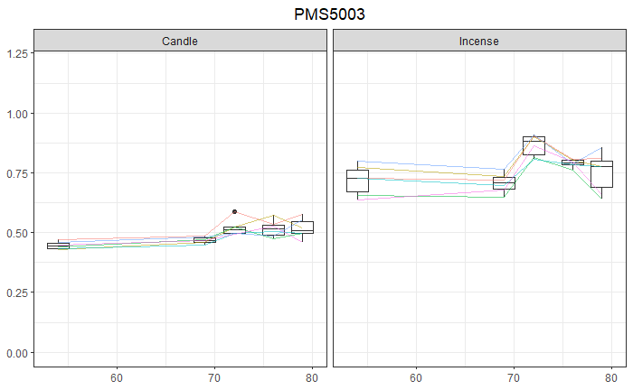

```r
customTheme<-theme_bw()+theme(legend.position = "none", axis.title.x=element_blank(), axis.title.y=element_blank(), plot.title = element_text(hjust = 0.5))

p_pms<-filter(res_rh_temp,slope_p_value<=0.05) %>%
  filter(grepl("PMS5003",sensor)) %>%
  ggplot() +
  geom_boxplot(aes(x = rh_median,y=slope,group=rh_median), size=0.5, fatten=0.8) +
  geom_line(aes(x = rh_median,y=slope, group = sensor, color = sensor,alpha=0.9)) +
  ylim(c(0,1.2))+
  facet_grid(~source) +
  ylab("Slope") +
  ggtitle("PMS5003") +
  xlab("Relative humidity (%)") +
  customTheme

p_pms
```

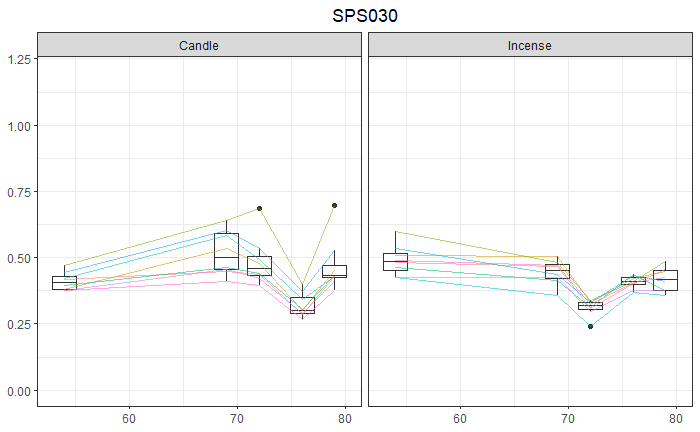

```r
p_opcr1<-filter(res_rh_temp,slope_p_value<=0.05) %>%
  filter(grepl("OPCR1",sensor)) %>%
  ggplot()+
  geom_boxplot(aes(x = rh_median,y=slope,group=rh_median), size=0.5, fatten=0.8)+
  geom_line(aes(x = rh_median,y=slope, group = sensor, color = sensor,alpha=0.9))+
  facet_grid(~source) +
  ylab("Slope") +
  ggtitle("OPCR1") +
  xlab("Relative humidity (%)") +
  customTheme

p_sps<-filter(res_rh_temp, slope_p_value<=0.05) %>%
  filter(grepl("SPS030",sensor)) %>%
  ggplot()+
  geom_boxplot(aes(x = rh_median, y = slope, group = rh_median), size=0.5, fatten=0.8)+
  geom_line(aes(x = rh_median, y = slope, group = sensor, color = sensor, alpha = 0.9))+
  ylim(c(0,1.2)) +
  facet_grid(~source) +
  ylab("Slope") +
  ggtitle("SPS030") +
  xlab("Relative humidity (%)") +
  customTheme


p_sds<-filter(res_rh_temp, slope_p_value <= 0.05) %>%
  filter(grepl("SDS018", sensor)) %>%
  ggplot() +
  geom_boxplot(aes(x = rh_median, y = slope, group = rh_median), size = 0.5, fatten = 0.8) +
  geom_line(aes(x = rh_median, y = slope, group = sensor, color = sensor, alpha = 0.9)) +
  ylim(c(0,1.2)) +
  facet_grid(~source) +
  ylab("Slope") +
  ggtitle("SDS018") +
  xlab("Relative humidity (%)") +
  customTheme

p_hpma<-filter(res_rh_temp, slope_p_value <= 0.05) %>%
  filter(grepl("HPMA115S0", sensor)) %>%
  ggplot() +
  geom_boxplot(aes(x = rh_median,y = slope, group = rh_median), size = 0.5, fatten = 0.8) +
  geom_line(aes(x = rh_median, y = slope, group = sensor, color = sensor, alpha = 0.9)) +
  ylim(c(0,1.2)) +
  facet_grid(~source) +
  ylab("Slope") +
  ggtitle("HPMA115S0") +
  xlab("Relative humidity (%)") +
  customTheme


pl_sig<-plot_grid(p_pms, p_sps, p_hpma, p_sds, p_opcr1, ncol = 2)
p_sps
```

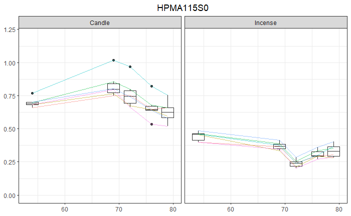

```r
p_hpma
```

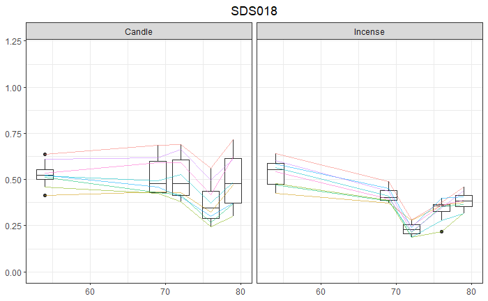

```r
p_sds
```

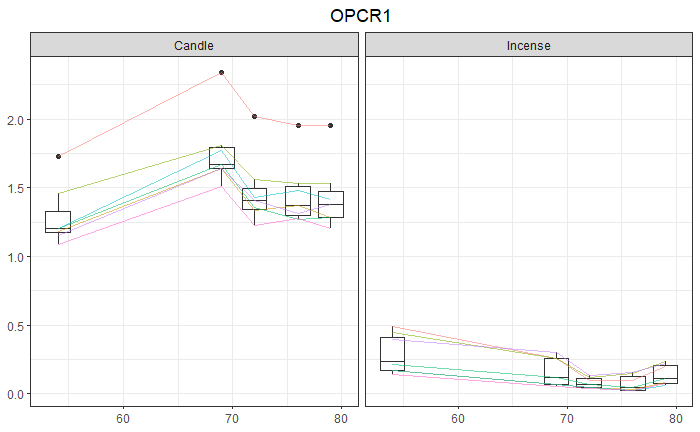

```r
p_opcr1
```

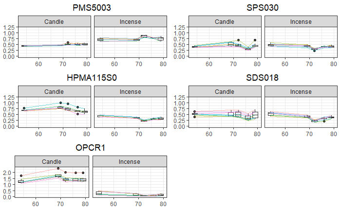

```r
pl_sig
```

```r
#ggsave(pl_sig, filename = "slope_evolution_sig.svg", width=200,height =200,units = "mm")
```

# R squared SIG with Box and Whisker

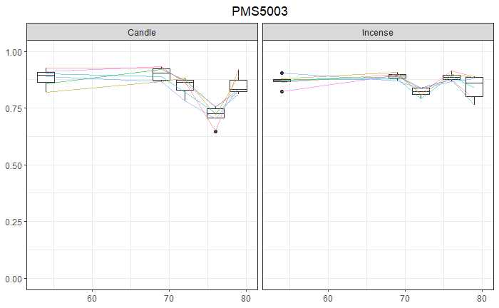

```r
p_pms<-filter(res_rh_temp,r_squared_p_value<=0.05) %>%
  filter(grepl("PMS5003",sensor)) %>%
  ggplot()+
  geom_boxplot(aes(x = rh_median,y=r_squared,group=rh_median), size=0.5, fatten=0.8)+
      geom_line(aes(x = rh_median,y=r_squared, group = sensor, color = sensor,alpha=0.9))+

 ylim(c(0,1))+
  facet_grid(~source)+theme_bw()+ylab("r_squared") + ggtitle("PMS5003") + xlab("Relative humidity (%)")+theme(legend.position = "none", axis.title.x=element_blank(), axis.title.y=element_blank(), plot.title = element_text(hjust = 0.5))
p_pms
```

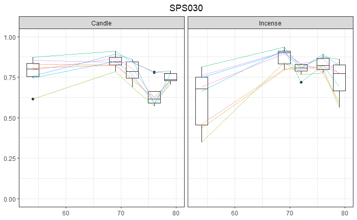

```r
p_opcr1<-filter(res_rh_temp,r_squared_p_value<=0.05) %>%
  filter(grepl("OPCR1",sensor)) %>%
   ggplot()+
 geom_boxplot(aes(x = rh_median,y=r_squared,group=rh_median), size=0.5, fatten=0.8)+
      geom_line(aes(x = rh_median,y=r_squared, group = sensor, color = sensor,alpha=0.9))+
     ylim(c(0,1))+
  facet_grid(~source)+theme_bw()+ylab("r_squared") + ggtitle("OPCR1") + xlab("Relative humidity (%)")+theme(legend.position = "none", axis.title.y=element_blank(), plot.title = element_text(hjust = 0.5))

p_sps<-filter(res_rh_temp, r_squared_p_value<=0.05) %>%
  filter(grepl("SPS030",sensor)) %>%
   ggplot()+
 geom_boxplot(aes(x = rh_median,y=r_squared,group=rh_median), size=0.5, fatten=0.8)+
      geom_line(aes(x = rh_median,y=r_squared, group = sensor, color = sensor,alpha=0.9))+
   ylim(c(0,1))+
  facet_grid(~source)+theme_bw()+ylab("r_squared") + ggtitle("SPS030")+xlab("Relative humidity (%)")+theme(legend.position = "none", axis.title.x=element_blank(), axis.title.y=element_blank(), plot.title = element_text(hjust = 0.5))


p_sds<-filter(res_rh_temp, r_squared_p_value<=0.05) %>%
  filter(grepl("SDS018",sensor)) %>%
   ggplot()+
  geom_boxplot(aes(x = rh_median,y=r_squared,group=rh_median), size=0.5, fatten=0.8)+
    geom_line(aes(x = rh_median,y=r_squared, group = sensor, color = sensor,alpha=0.9))+
   ylim(c(0,1))+
  facet_grid(~source)+theme_bw()+ylab("r_squared") + ggtitle("SDS018") + xlab("Relative humidity (%)")+theme(legend.position = "none", axis.title.x=element_blank(), axis.title.y=element_blank(), plot.title = element_text(hjust = 0.5))

p_hpma<-filter(res_rh_temp, r_squared_p_value<=0.05) %>%
  filter(grepl("HPMA115S0",sensor)) %>%
  ggplot()+
  geom_boxplot(aes(x = rh_median,y=r_squared,group=rh_median), size=0.5, fatten=0.8)+
      geom_line(aes(x = rh_median,y=r_squared, group = sensor, color = sensor,alpha=0.9))+
   ylim(c(0,1))+
  facet_grid(~source)+theme_bw()+ylab("r_squared") + ggtitle("HPMA115S0") + xlab("Relative humidity (%)")+theme(legend.position = "none", axis.title.x=element_blank(), axis.title.y=element_blank(), plot.title = element_text(hjust = 0.5))


pl_sig<-plot_grid(p_pms, p_sps, p_hpma, p_sds, p_opcr1, ncol = 2)
p_sps
```

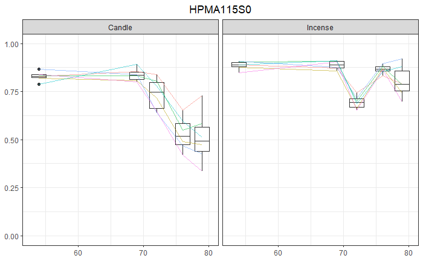

```r
p_hpma
```

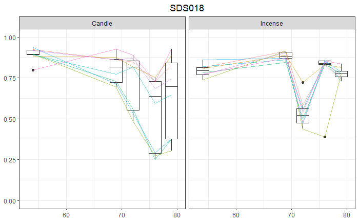

```r
p_sds
```

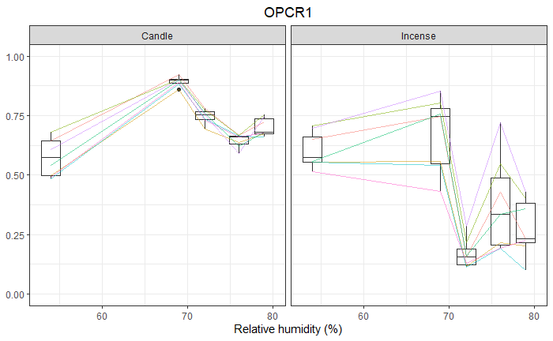

```r
p_opcr1
```

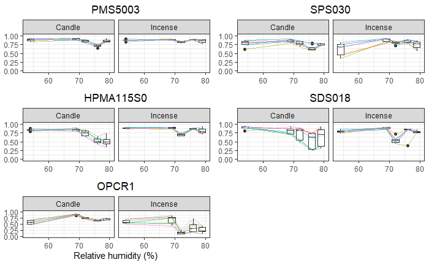

```r
pl_sig
```

```r
require(plotly)
ggplotly(pl_sig)
```

[output not shown]

[interactive chart not shown]

```r
#ggsave(pl_sig, filename = "r_squared_evolution_sig.svg", width=200,height =200,units = "mm")
```